# Предварительные оценки фенологических параметров

Вадим Хайтов

16 января 2019 г

Ниже приводится описание алгоритма вычисления фенологических характеристик для популяций трех видов планктонных копепод.

## Прнцип вычисления фенологических параметров

В качестве параметров, характеризующих фенологию предлагается использовать (где это возможно) параметры вычисляемые на основе модели, описывающей зависимость между временем ($date$) и накопленным числом особей ($CumN$). Такая кумулятивная модель может быть описана самыми разными функциями, в том числе логистической кривой, параметры которой достаточно легко могут быть оценены.

Всего для построения логистической кривой надо подобрать три параметра: **Asym** (асимптота, максимально возможная накопленная сумма), **xmid** (точка перегиба логистической кривой, она соответствует пику в графике динамики численности), **scal** Параметр, в принципе, характеризующий крутизну подъема кумуляты. Его можно использовать в качестве оценки степени растянутости пика, присутствия вида в планктоне.

Логистическая кривая описывается следующим уравнением

$$CumN = \frac{Asym}{1+e^{(xmid-date)/scal}}$$

Дата точки перегиба соответствует и 50% квантилю накопленного числа особей.

Помимо этого значения можно использовать еще 15% и 85% квантили, которые можно трактовать как дату начала и окончания присутствия вида в планктоне. Для вычисления времени, соответствующего этим событиям надо взять обратную от логистической функцию и подставить туда $0.15Asym$ или $0.85Asym$.

Вот примеры таких кривых.

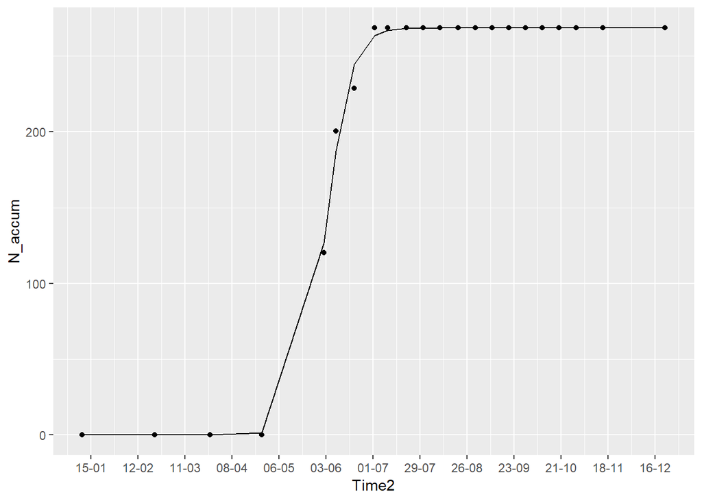

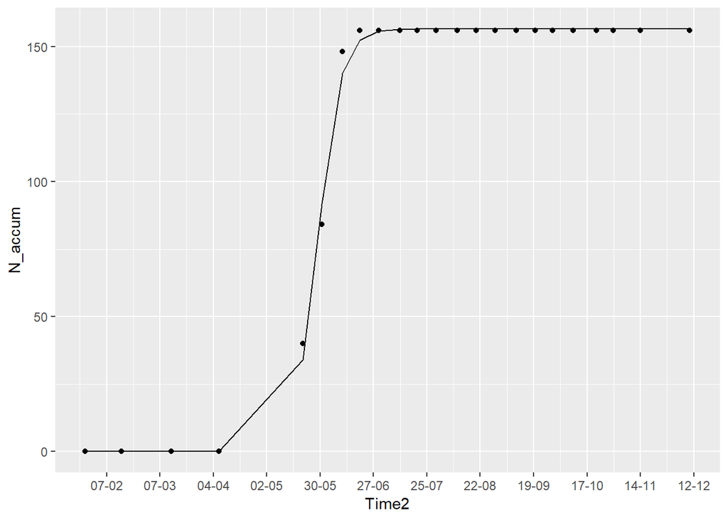

Для Centropages в 1978 году видно, что здесь пики более размазанные.

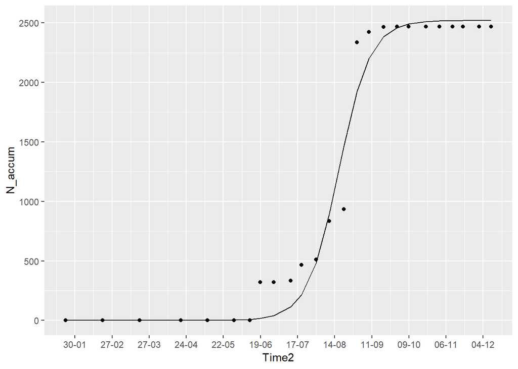

А вот у Temora в этом же 1978 году более узкий пик.

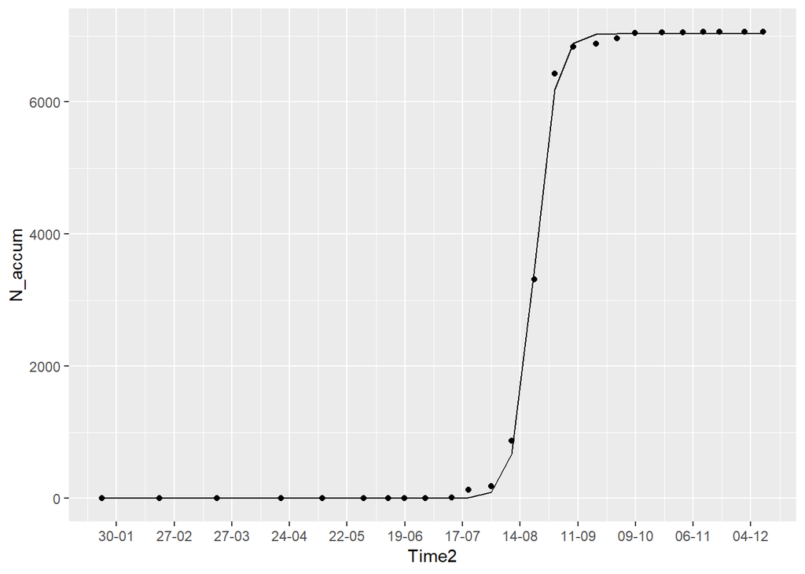

Таким образом, по подобранной модели можно достаточно хорошо оценить фенологические показатели.

Однако есть и ЗА и ПРОТИВ использования такого подхода.

ЗА: - Все легко вычисляется, если есть модель. - Можно характеризовать время пика, время начала, время конца сезона расцвета для вида. - Можно численно характеризовать “остроту” пика.

ПРОТИВ: - Не всегда можно вычислить параметры логистической модели.

Это происходит если пик был очень кратким. Собственно такая проблема встала только в случае Calanus. Совсем же безобразие было в 1972 году, когда этот вид вообще не был отмечен в планктоне (в анализе участвовали только особи CopI стадии, может другие стадии и были).

## Фенологические таблицы для каждого из видов.

Вот то, что удалось посчитать для каждого из видов

### Calanus

Во всех случаях даты - это количество Юлианских дней от 01.01 соответствующего года.

| Год | Asym | xmid | scal | Дата 15% | Дата 50% | Дата 85% | Дата реально отмеченного пика |
| --- | --- | --- | --- | --- | --- | --- | --- |
| 1961 | NA | NA | NA | NA | NA | NA | 165.0 |
| 1962 | NA | NA | NA | NA | NA | NA | 161.0 |
| 1963 | NA | NA | NA | NA | NA | NA | 162.0 |
| 1964 | 109.40383 | -174748507 | 256587.39 | 164 | 169 | 175 | 171.0 |
| 1965 | 200.03329 | -143951256 | 363288.44 | 153 | 160 | 167 | 160.0 |
| 1966 | NA | NA | NA | NA | NA | NA | 200.0 |
| 1967 | 106.40098 | -81542487 | 196792.36 | 148 | 152 | 156 | 160.0 |
| 1968 | 60.76474 | -49693591 | 458603.43 | 147 | 156 | 165 | 161.0 |
| 1969 | NA | NA | NA | NA | NA | NA | 181.0 |
| 1970 | 65.00334 | 14239926 | 148349.68 | 162 | 165 | 168 | 171.0 |
| 1971 | 105.73828 | 47275392 | 160429.10 | 179 | 182 | 185 | 190.0 |
| 1972 | NA | NA | NA | NA | NA | NA | 247.8 |
| 1973 | 91.69130 | 107499472 | 243188.24 | 143 | 148 | 153 | 150.0 |
| 1974 | NA | NA | NA | NA | NA | NA | 160.0 |
| 1975 | 282.19947 | 170748088 | 197929.53 | 146 | 150 | 154 | 151.0 |
| 1976 | 166.20205 | 202434411 | 217525.91 | 148 | 152 | 156 | 152.0 |
| 1977 | NA | NA | NA | NA | NA | NA | 163.0 |
| 1978 | 704.12095 | 266199194 | 195536.78 | 155 | 159 | 163 | 161.0 |
| 1979 | NA | NA | NA | NA | NA | NA | 171.0 |
| 1980 | 50.15957 | 329302976 | 134143.10 | 157 | 159 | 162 | 162.0 |
| 1981 | 524.96905 | 360610450 | 461989.97 | 146 | 156 | 165 | 160.0 |
| 1982 | 62.89710 | 391701758 | 649963.65 | 138 | 151 | 164 | 149.0 |
| 1983 | 35.23606 | 423986711 | 441328.08 | 150 | 159 | 168 | 170.0 |
| 1984 | 211.84329 | 454726310 | 165303.41 | 147 | 150 | 153 | 151.0 |
| 1985 | 596.14644 | 487977779 | 213734.33 | 165 | 169 | 173 | 170.0 |
| 1986 | 369.56339 | 518447575 | 104169.37 | 154 | 157 | 159 | 159.0 |
| 1987 | 236.92490 | 550721601 | 363417.66 | 158 | 165 | 172 | 170.0 |
| 1988 | 56.35389 | 581080467 | 293869.43 | 146 | 151 | 157 | 154.0 |
| 1989 | 180.32368 | 612967483 | 318051.57 | 148 | 155 | 161 | 161.0 |
| 1990 | NA | NA | NA | NA | NA | NA | 169.0 |
| 1991 | 209.03220 | 677205133 | 131186.75 | 165 | 168 | 171 | 170.0 |
| 1992 | 1012.83701 | 706983929 | 810752.45 | 131 | 148 | 164 | 152.0 |
| 1993 | 383.86079 | 739390930 | 206145.06 | 153 | 157 | 161 | 160.0 |
| 1994 | 1086.60056 | 771288942 | 136957.61 | 158 | 161 | 164 | 170.0 |
| 1995 | 361.42882 | 801595373 | 520835.63 | 136 | 147 | 157 | 151.0 |
| 1996 | 268.53042 | 833729944 | 639124.57 | 141 | 154 | 166 | 153.0 |
| 1997 | 164.61265 | 866935750 | 99350.79 | 170 | 172 | 174 | 180.0 |
| 1998 | 414.80010 | 898646462 | 100961.88 | 172 | 174 | 176 | 180.0 |
| 1999 | NA | NA | NA | NA | NA | NA | 171.0 |
| 2000 | 343.73998 | 959819988 | 199738.87 | 148 | 152 | 156 | 161.0 |
| 2001 | 90.63778 | 991596647 | 405207.56 | 146 | 154 | 162 | 161.0 |
| 2002 | NA | NA | NA | NA | NA | NA | 161.0 |
| 2003 | 382.74067 | 1054198332 | 200571.41 | 144 | 148 | 152 | 150.0 |
| 2004 | 80.89920 | 1086359885 | 295875.89 | 150 | 156 | 162 | 161.0 |
| 2005 | NA | NA | NA | NA | NA | NA | 161.0 |
| 2006 | 597.14148 | 1149266674 | 186242.54 | 149 | 153 | 156 | 160.0 |
| 2007 | 255.15854 | 1180045083 | 495187.98 | 134 | 144 | 154 | 140.0 |
| 2008 | 396.13703 | 1212575093 | 260824.30 | 150 | 155 | 161 | 162.0 |
| 2009 | 243.46385 | 1244678405 | 291618.38 | 155 | 161 | 167 | 170.0 |
| 2010 | NA | NA | NA | NA | NA | NA | 160.0 |
| 2011 | 156.56317 | 1306599858 | 529653.88 | 137 | 148 | 158 | 161.0 |
| 2012 | 308.15406 | 1338265475 | 179851.80 | 146 | 149 | 153 | 151.0 |
| 2013 | 386.79701 | 1370076856 | 189571.63 | 148 | 151 | 155 | 160.0 |
| 2014 | 139.64592 | 1402229088 | 161870.37 | 155 | 159 | 162 | 160.0 |
| 2015 | NA | NA | NA | NA | NA | NA | 160.0 |
| 2016 | 282.20308 | 1463652144 | 236117.26 | 135 | 139 | 144 | 144.0 |
| 2017 | 1781.61501 | 1496762912 | 422505.09 | 148 | 157 | 165 | 155.0 |
| 2018 | 368.58905 | 1526747488 | 94312.33 | 137 | 139 | 141 | 139.0 |

`NA` стоит в тех случаях, когда модель подобрать не удалось. Однако надо подумать, может в таких случаях в качестве параметра “Дата 50%” брать дату пика, реально отмеченного в наблюдениях. Надо также подумать, как в такой ситуации оценить параметры “Дата 15%” и “Дата 85%”.

Для иллюстрации того, что параметр **scal** может характеризовать растянутость периода и, соответственно, тоже является фенологическим параметром можем посмотреть на связь между значением этого параметра и разницей между датой 85% и датой 15%. Корреляция очевидная и очень высокая. Так что я бы и этот параметр (**scal**) тоже включил бы в фенологическую матрицу.

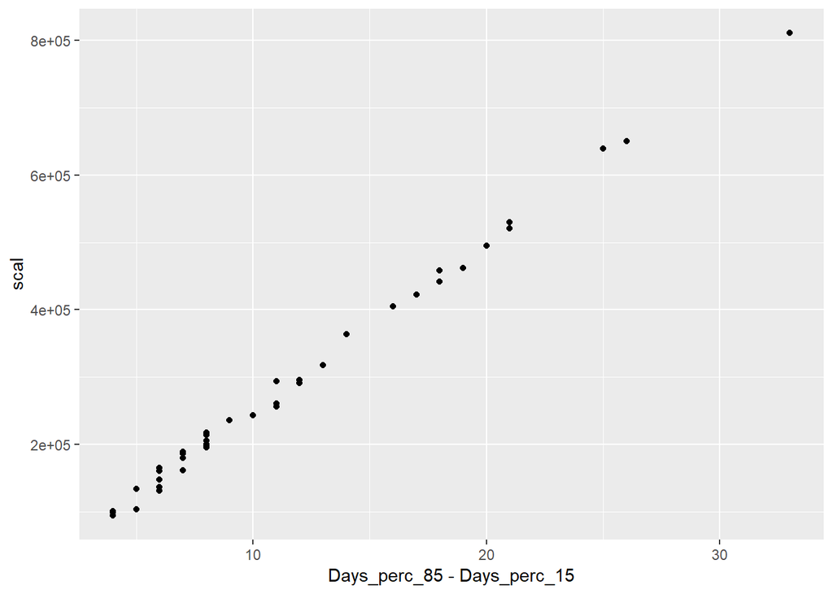

Чтобы проверить посмотреть насколько соотносится расчетная величина наступления пика (синяя линия) с физическим пиком, отмеченным в наблюдениях (красная линия), можно посмотреть следующую серию картинок.

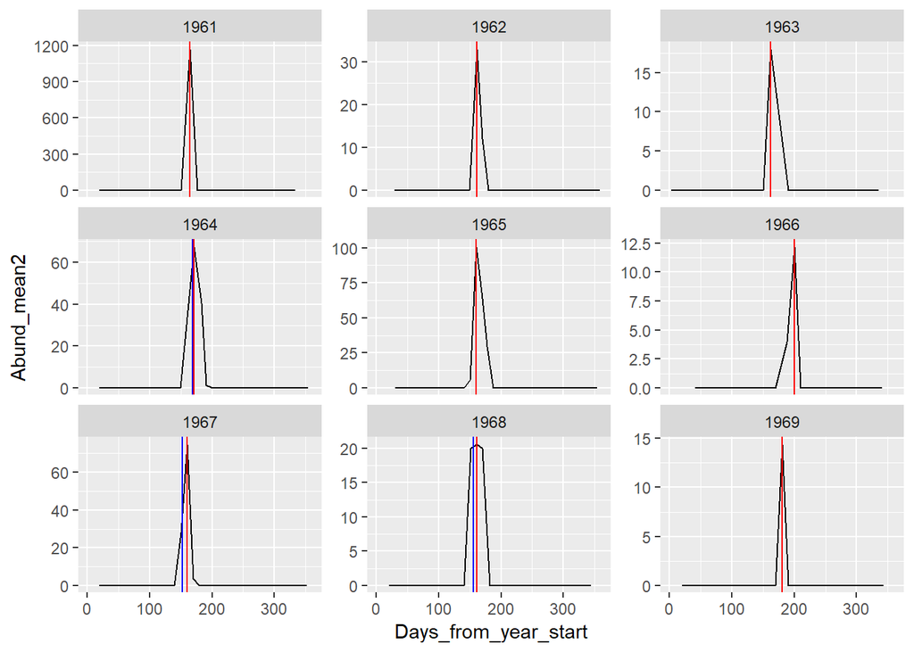

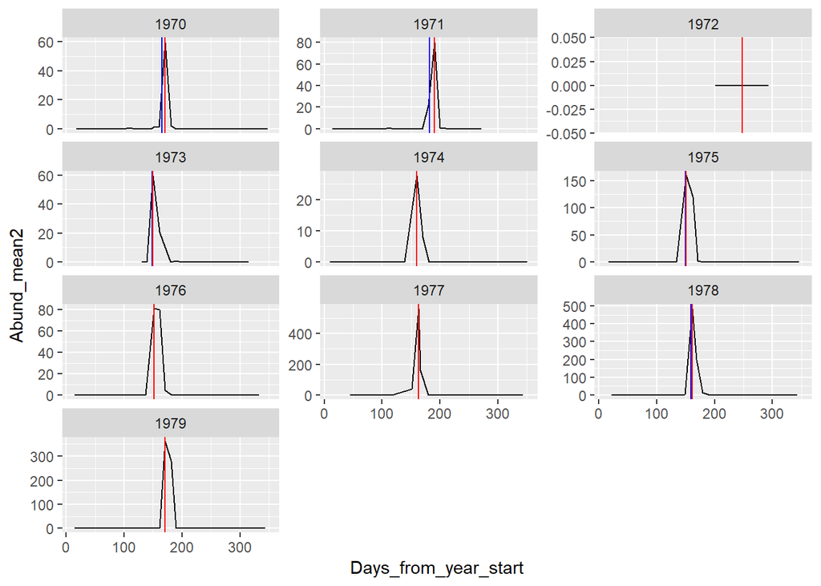

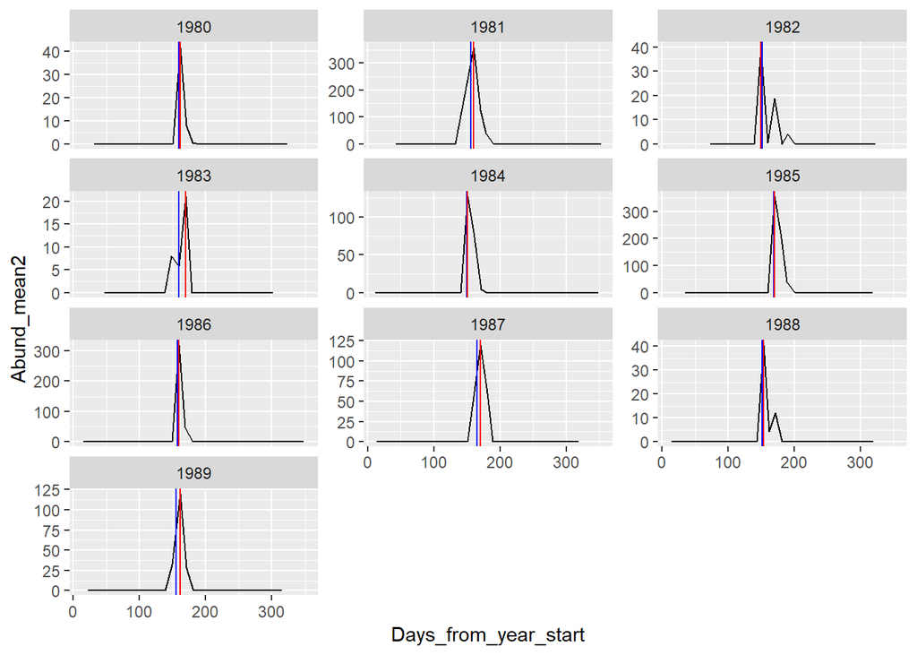

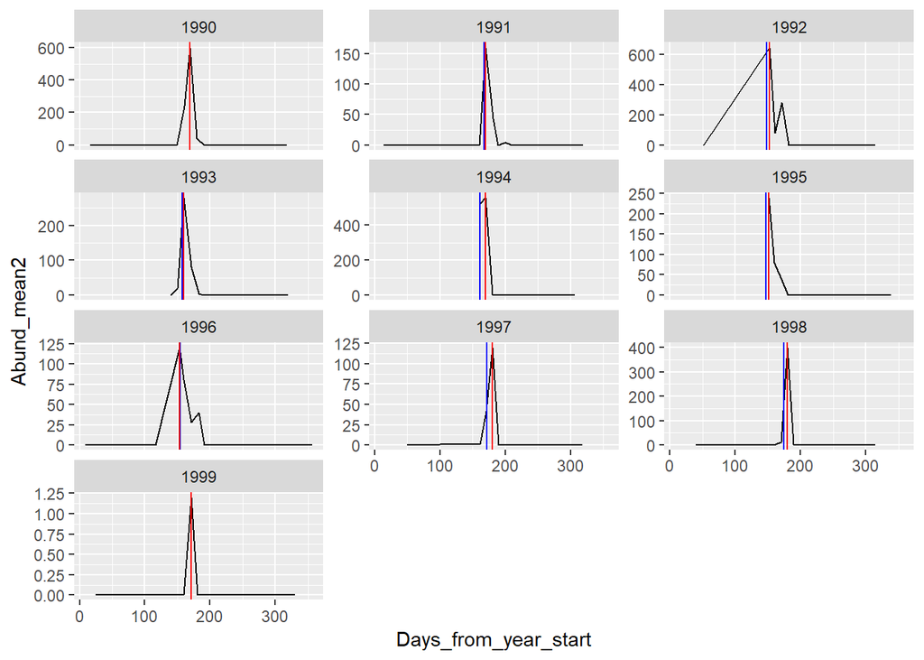

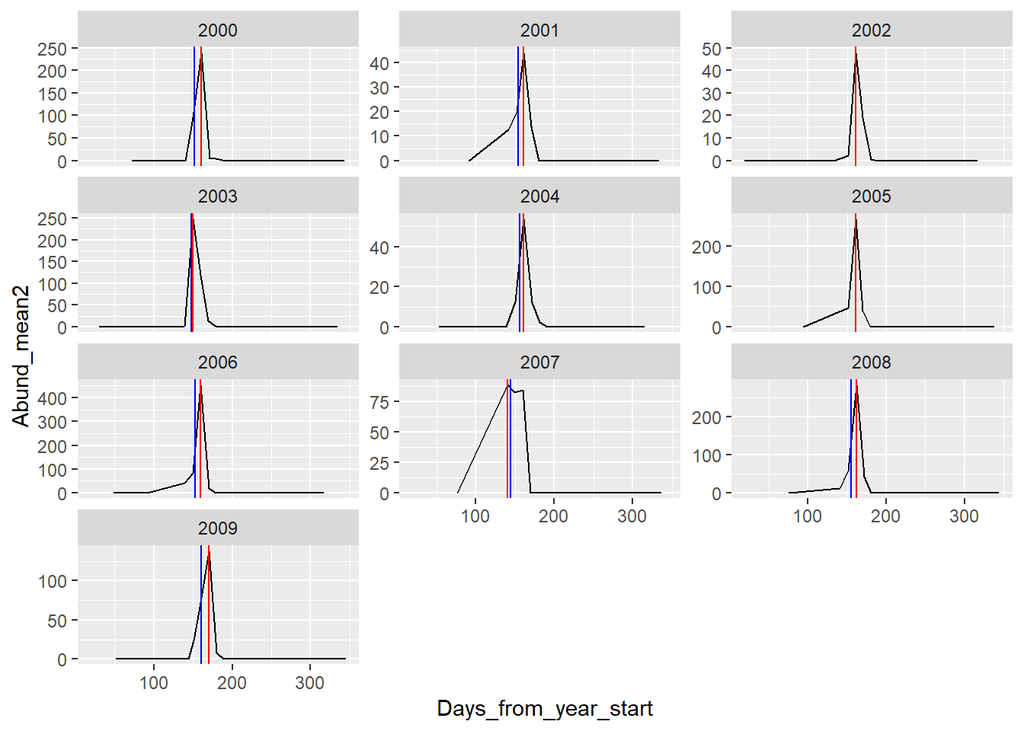

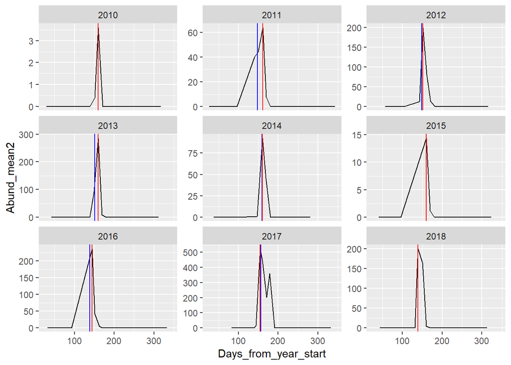

### Centropages

| Год | Asym | xmid | scal | Дата 15% | Дата 50% | Дата 85% | Дата реально отмеченного пика |
| --- | --- | --- | --- | --- | --- | --- | --- |
| 1961 | 499.18786 | -265207210 | 981108.5 | 198 | 217 | 237 | 221.0 |
| 1962 | 70.68778 | -232585988 | 2117784.6 | 188 | 230 | 273 | 262.0 |
| 1963 | 235.84908 | -201702146 | 548227.8 | 211 | 222 | 233 | 221.0 |
| 1964 | 261.01787 | -170904517 | 628845.4 | 201 | 214 | 227 | 212.0 |
| 1965 | 834.51445 | -138867023 | 1430333.0 | 190 | 219 | 247 | 241.0 |
| 1966 | 619.78110 | -105231415 | 259930.2 | 238 | 243 | 248 | 252.0 |
| 1967 | 847.32670 | -76070295 | 1000472.9 | 195 | 216 | 236 | 221.0 |
| 1968 | 161.81396 | -44957255 | 980091.7 | 191 | 211 | 230 | 201.0 |
| 1969 | 1301.02893 | -11209344 | 354600.0 | 228 | 235 | 242 | 241.0 |
| 1970 | 877.33147 | 20324723 | 981637.9 | 216 | 235 | 255 | 242.0 |
| 1971 | 778.07892 | 52123360 | 317910.6 | 232 | 238 | 245 | 242.0 |
| 1972 | 551.37123 | 82168725 | 979617.5 | 201 | 221 | 241 | 222.0 |
| 1973 | 1122.68542 | 115123420 | 680736.9 | 223 | 236 | 250 | 241.0 |
| 1974 | 421.15964 | 146631215 | 396140.3 | 228 | 236 | 244 | 241.0 |
| 1975 | 362.68046 | 176077388 | 665163.7 | 199 | 212 | 225 | 221.0 |
| 1976 | 104.36065 | 206384327 | 1737863.2 | 163 | 198 | 233 | 196.5 |
| 1977 | 475.17916 | 239565608 | 336752.8 | 209 | 216 | 223 | 216.0 |
| 1978 | 2519.38456 | 272158693 | 1023609.6 | 207 | 228 | 249 | 242.0 |
| 1979 | 620.56795 | 304486574 | 670292.0 | 224 | 237 | 251 | 241.0 |
| 1980 | 656.84974 | 334998395 | 494690.9 | 215 | 225 | 235 | 223.0 |
| 1981 | 278.77884 | 367599576 | 664824.1 | 223 | 237 | 250 | 242.0 |
| 1982 | 44.86226 | 398795445 | 940610.1 | 214 | 233 | 252 | 252.0 |
| 1983 | 382.16451 | 431003014 | 1447849.7 | 211 | 240 | 270 | 253.0 |
| 1984 | 1906.52303 | 462443627 | 526678.2 | 229 | 239 | 250 | 253.0 |
| 1985 | 1440.61727 | 492684508 | 857734.1 | 206 | 223 | 241 | 220.0 |
| 1986 | 2599.44747 | 523302522 | 842656.8 | 196 | 213 | 230 | 211.0 |
| 1987 | 1612.85011 | 556527726 | 936515.8 | 213 | 232 | 251 | 230.0 |
| 1988 | 1699.36377 | 585752698 | 952620.0 | 186 | 206 | 225 | 200.0 |
| 1989 | 2771.10379 | 618294580 | 767529.7 | 201 | 216 | 232 | 230.0 |
| 1990 | 420.45725 | 650375501 | 508724.3 | 212 | 222 | 233 | 231.0 |
| 1991 | 909.23855 | 682472389 | 817402.2 | 213 | 229 | 245 | 232.0 |
| 1992 | 3606.26518 | 714520385 | 1037470.4 | 214 | 235 | 256 | 243.0 |
| 1993 | 2499.50800 | 745030743 | 1090962.4 | 200 | 222 | 244 | 232.0 |
| 1994 | 2273.84124 | 776681082 | 804174.6 | 207 | 223 | 240 | 231.0 |
| 1995 | 604.98482 | 808283006 | 1414214.1 | 196 | 224 | 253 | 241.0 |
| 1996 | 383.59436 | 841301758 | 807796.8 | 225 | 241 | 258 | 253.0 |
| 1997 | 3458.87042 | 871933862 | 587265.8 | 218 | 230 | 242 | 231.0 |
| 1998 | 1470.18141 | 903170836 | 1003796.6 | 206 | 226 | 247 | 231.0 |
| 1999 | 1131.45224 | 934874894 | 1183178.0 | 205 | 228 | 252 | 241.0 |
| 2000 | 2770.41130 | 965111985 | 488954.5 | 203 | 213 | 223 | 213.0 |
| 2001 | 1563.47921 | 997508754 | 758793.5 | 207 | 222 | 237 | 241.0 |
| 2002 | 1003.46334 | 1028989349 | 1147711.4 | 199 | 222 | 245 | 231.0 |
| 2003 | 2240.35797 | 1059512883 | 498831.2 | 200 | 210 | 220 | 222.0 |
| 2004 | 453.23103 | 1091565147 | 813692.6 | 200 | 216 | 232 | 222.0 |
| 2005 | 1810.43205 | 1123336502 | 735915.7 | 203 | 218 | 232 | 231.0 |
| 2006 | 951.99731 | 1154191646 | 1263485.8 | 184 | 210 | 235 | 221.0 |
| 2007 | 394.85695 | 1186003684 | 1826953.1 | 176 | 213 | 250 | 241.0 |
| 2008 | 1105.38016 | 1214981850 | 1387386.8 | 155 | 183 | 211 | 172.0 |
| 2009 | 1808.60492 | 1247139538 | 425641.1 | 181 | 189 | 198 | 189.0 |
| 2010 | 539.19940 | 1283113983 | 883700.6 | 223 | 241 | 259 | 251.0 |
| 2011 | 1507.11117 | 1312361691 | 524581.4 | 204 | 214 | 225 | 221.0 |
| 2012 | 1454.74520 | 1343550870 | 1852275.9 | 173 | 210 | 248 | 221.0 |
| 2013 | 5440.32040 | 1374538164 | 307945.2 | 197 | 203 | 209 | 211.0 |
| 2014 | 2087.70894 | 1407980741 | 1293845.5 | 199 | 225 | 251 | 231.0 |
| 2015 | 1444.74880 | 1437713075 | 630680.7 | 192 | 204 | 217 | 210.0 |
| 2016 | 578.92908 | 1470712160 | 1101693.3 | 199 | 221 | 243 | 232.0 |
| 2017 | 809.77652 | 1502033360 | 1385015.3 | 190 | 218 | 245 | 233.0 |
| 2018 | 799.03422 | 1533605190 | 837258.7 | 201 | 218 | 235 | 220.0 |

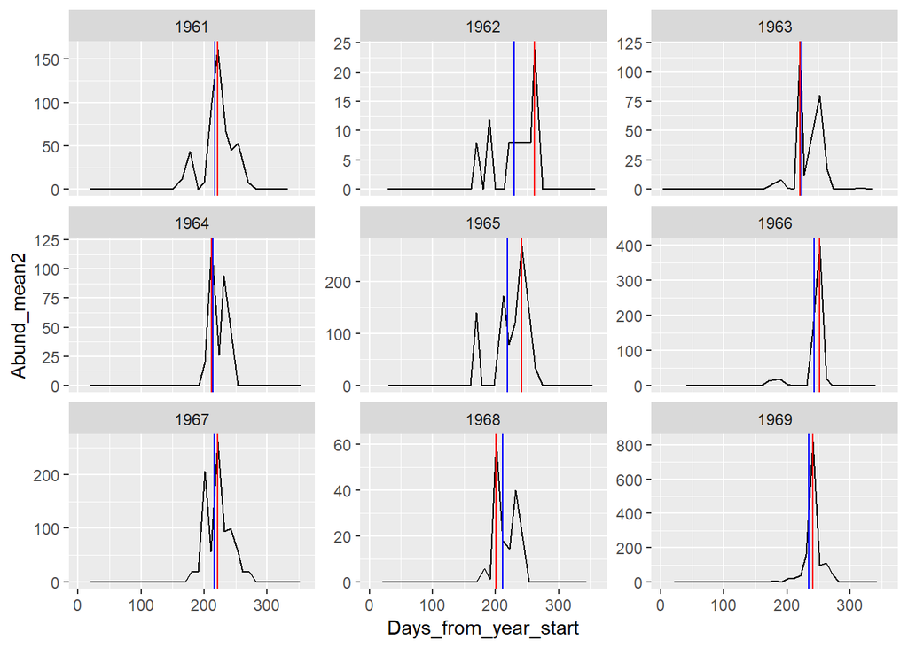

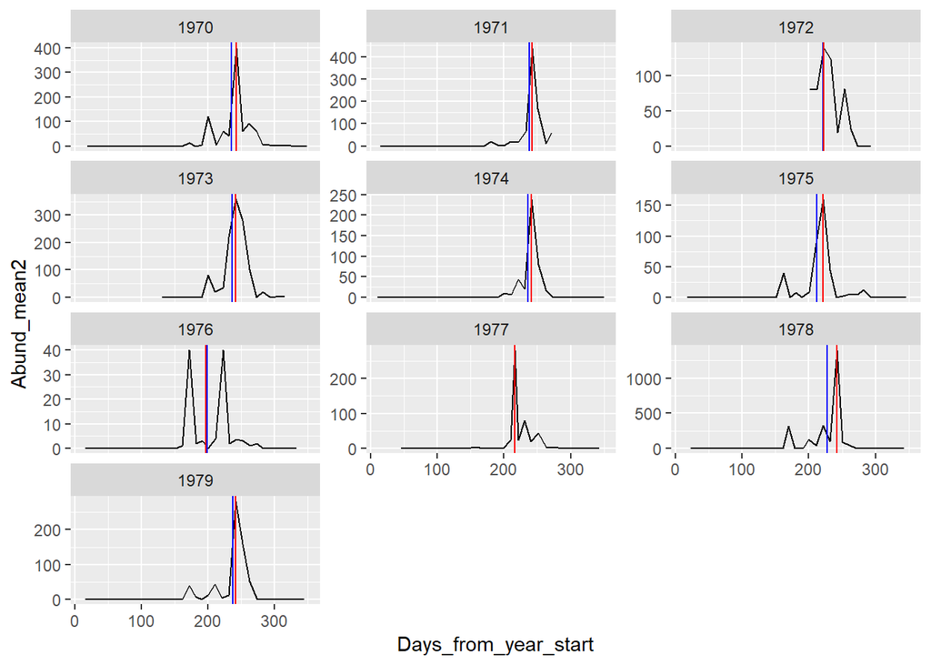

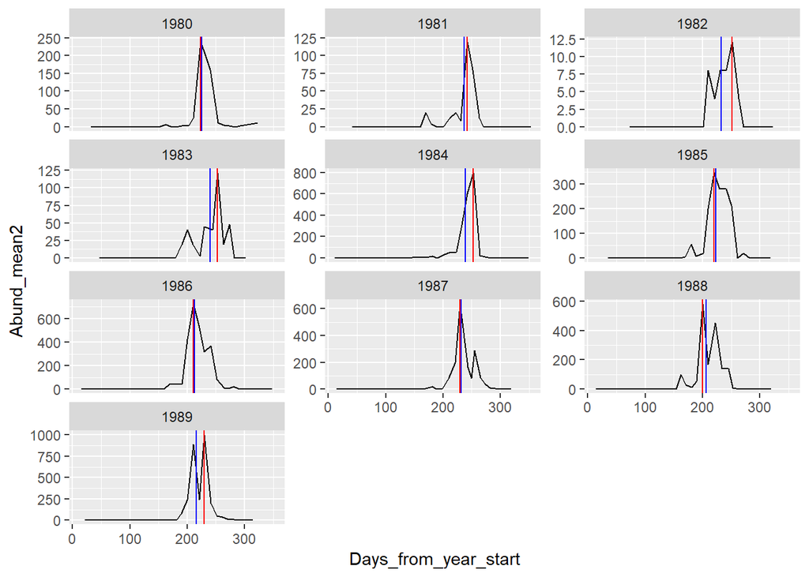

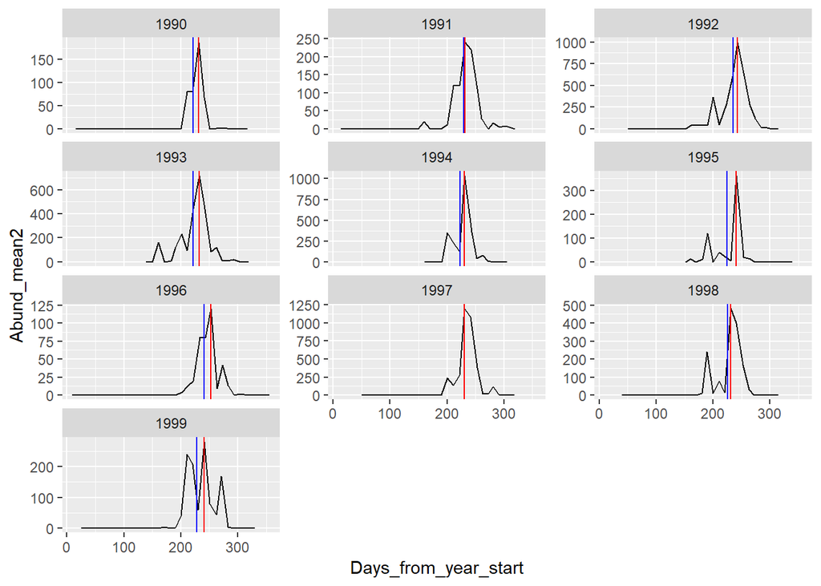

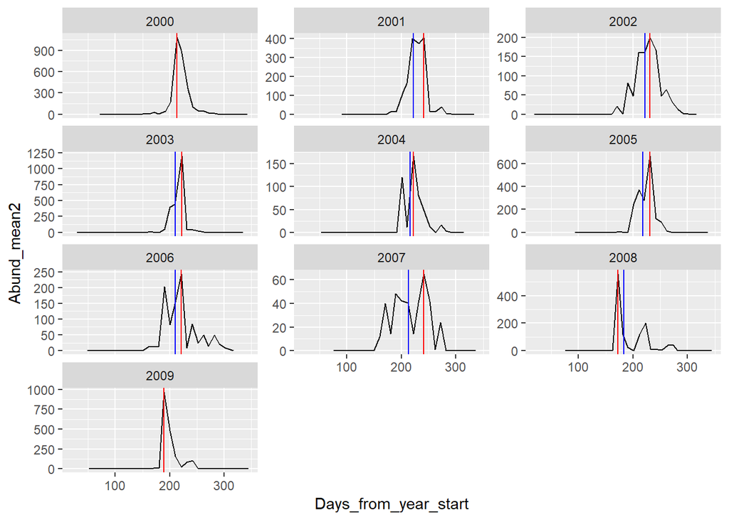

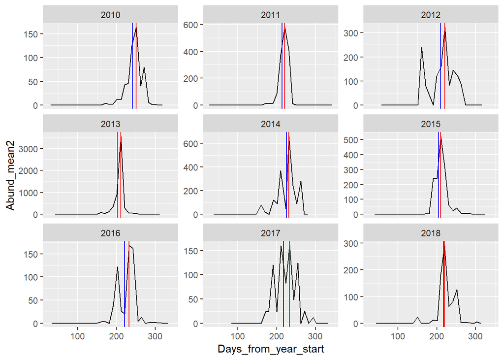

### Temora

| Год | Asym | xmid | scal | Дата 15% | Дата 50% | Дата 85% | Дата реально отмеченного пика |
| --- | --- | --- | --- | --- | --- | --- | --- |
| 1961 | 4155.9410 | -264381966 | 935896.4 | 208 | 227 | 246 | 234 |
| 1962 | 4151.4074 | -231844418 | 637519.4 | 226 | 239 | 251 | 246 |
| 1963 | 3739.5182 | -200409422 | 1040940.6 | 217 | 237 | 258 | 252 |
| 1964 | 1440.9559 | -169892215 | 693642.4 | 212 | 226 | 240 | 231 |
| 1965 | 5407.5492 | -135854762 | 1322012.0 | 227 | 254 | 280 | 241 |
| 1966 | 752.6289 | -104685893 | 514835.2 | 239 | 249 | 260 | 262 |
| 1967 | 1577.0498 | -73436646 | 504978.4 | 236 | 246 | 256 | 253 |
| 1968 | 3427.0244 | -41656738 | 432988.0 | 240 | 249 | 258 | 253 |
| 1969 | 697.2597 | -9670602 | 1030137.5 | 232 | 253 | 274 | 241 |
| 1970 | 1712.2642 | 21729967 | 980512.4 | 232 | 252 | 271 | 242 |
| 1971 | 1802.5451 | 51446332 | 1440591.7 | 202 | 230 | 259 | 242 |
| 1972 | 786.0900 | 83796606 | 1046825.2 | 219 | 240 | 261 | 233 |
| 1973 | 2802.3402 | 116158942 | 1107836.0 | 226 | 248 | 271 | 241 |
| 1974 | 10626.6279 | 145890219 | 391458.9 | 220 | 228 | 235 | 231 |
| 1975 | 2390.6665 | 180217569 | 1893645.0 | 222 | 260 | 298 | 273 |
| 1976 | 1462.0106 | 210256837 | 782425.5 | 227 | 243 | 258 | 252 |
| 1977 | 2339.8450 | 240648498 | 840449.6 | 211 | 228 | 245 | 231 |
| 1978 | 7040.3827 | 272504695 | 428496.7 | 223 | 232 | 241 | 242 |
| 1979 | 1497.6322 | 305750187 | 559576.8 | 241 | 252 | 263 | 262 |
| 1980 | 8138.4262 | 335899281 | 950673.7 | 217 | 236 | 255 | 223 |
| 1981 | 2343.3819 | 368151883 | 938857.3 | 224 | 243 | 262 | 252 |
| 1982 | 1208.9198 | 399608435 | 1288730.5 | 216 | 242 | 268 | 252 |
| 1983 | 843.4559 | 431377726 | 1069248.6 | 223 | 245 | 266 | 253 |
| 1984 | 15927.8208 | 462716508 | 506972.2 | 232 | 243 | 253 | 253 |
| 1985 | 8041.4726 | 493546491 | 947334.4 | 214 | 233 | 252 | 230 |
| 1986 | 4475.2631 | 525615838 | 1110497.2 | 217 | 240 | 262 | 252 |
| 1987 | 5195.0007 | 557924146 | 648022.3 | 235 | 248 | 261 | 255 |
| 1988 | 2737.7703 | 588770675 | 952427.0 | 221 | 240 | 260 | 234 |
| 1989 | 7426.3708 | 619530598 | 780223.6 | 215 | 230 | 246 | 230 |
| 1990 | 4947.1366 | 652185954 | 1381560.1 | 216 | 243 | 271 | 273 |
| 1991 | 2217.9100 | 682381916 | 457008.8 | 219 | 228 | 237 | 232 |
| 1992 | 4389.5225 | 715331025 | 698053.8 | 230 | 244 | 258 | 253 |
| 1993 | 5380.6851 | 746627704 | 572448.2 | 229 | 241 | 252 | 242 |
| 1994 | 4408.5714 | 777508108 | 746113.8 | 218 | 233 | 248 | 243 |
| 1995 | 738.9842 | 809655703 | 1948297.2 | 201 | 240 | 279 | 253 |
| 1996 | 1618.6482 | 841351764 | 900080.1 | 224 | 242 | 260 | 253 |
| 1997 | 6146.5057 | 872424953 | 723785.7 | 221 | 236 | 250 | 231 |
| 1998 | 7646.7246 | 903677296 | 747076.9 | 217 | 232 | 247 | 241 |
| 1999 | 1724.3669 | 936327524 | 1177526.1 | 221 | 245 | 269 | 262 |
| 2000 | 6774.4140 | 966616783 | 1215054.7 | 206 | 231 | 255 | 213 |
| 2001 | 1345.7922 | 998466753 | 1240553.9 | 208 | 233 | 258 | 232 |
| 2002 | 3157.1054 | 1031580207 | 916191.7 | 233 | 252 | 270 | 252 |
| 2003 | 4004.4669 | 1061229771 | 1166530.5 | 206 | 230 | 253 | 222 |
| 2004 | 1957.3570 | 1092849296 | 1053434.5 | 210 | 231 | 252 | 222 |
| 2005 | 3054.6218 | 1123707155 | 889549.7 | 204 | 222 | 240 | 231 |
| 2006 | 578.9009 | 1154391011 | 2220407.8 | 167 | 212 | 257 | 170 |
| 2007 | 2905.1860 | 1188121046 | 909159.9 | 219 | 237 | 256 | 241 |
| 2008 | 8099.2989 | 1218150331 | 1906141.5 | 182 | 220 | 258 | 212 |
| 2009 | 1155.8514 | 1249203188 | 1073640.6 | 192 | 213 | 235 | 231 |
| 2010 | 1730.2445 | 1283133024 | 653725.4 | 228 | 241 | 254 | 251 |
| 2011 | 6597.8242 | 1312563120 | 711327.4 | 202 | 217 | 231 | 221 |
| 2012 | 12172.7265 | 1346269491 | 968412.7 | 222 | 242 | 261 | 253 |
| 2013 | 7735.7138 | 1375055295 | 865401.0 | 192 | 209 | 226 | 211 |
| 2014 | 7128.3075 | 1407767289 | 1202113.4 | 198 | 223 | 247 | 231 |
| 2015 | 1704.5622 | 1440920233 | 1131389.7 | 219 | 241 | 264 | 263 |
| 2016 | 5111.8315 | 1471083614 | 598439.6 | 213 | 225 | 237 | 232 |
| 2017 | 4122.7513 | 1504274392 | 1661272.8 | 210 | 244 | 277 | 272 |
| 2018 | 1847.5106 | 1534948868 | 987415.7 | 214 | 234 | 253 | 220 |

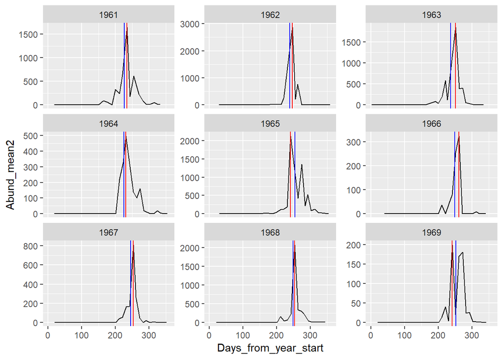

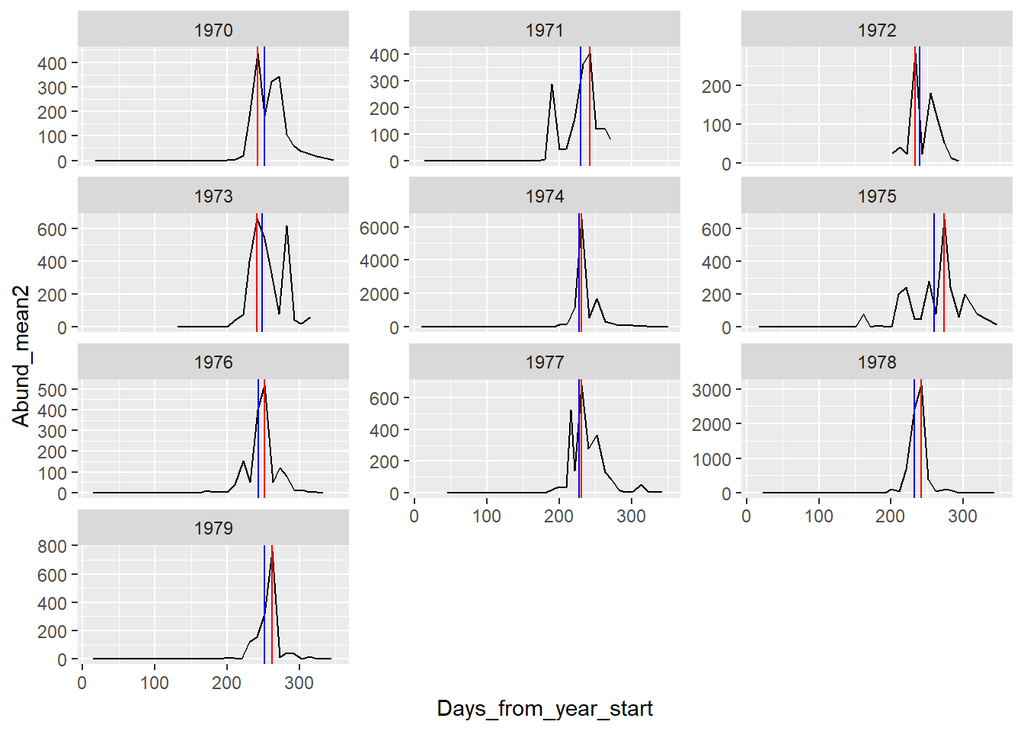

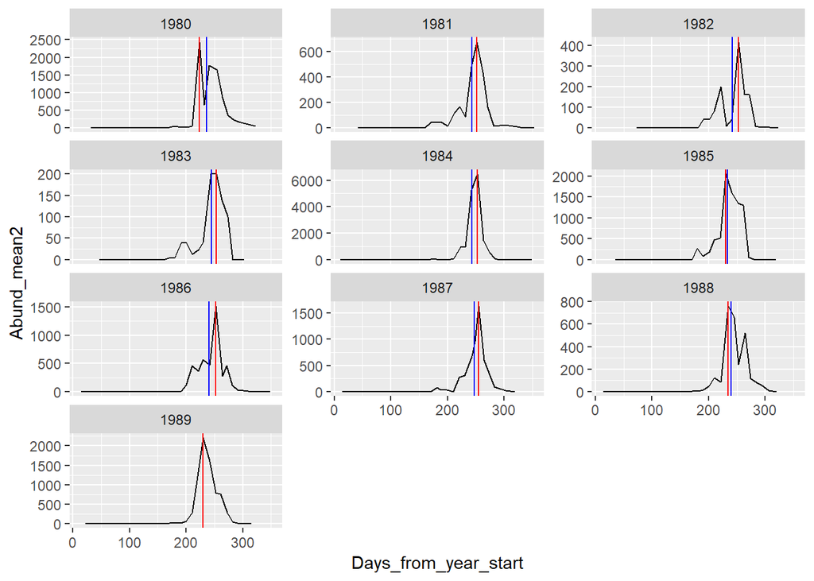

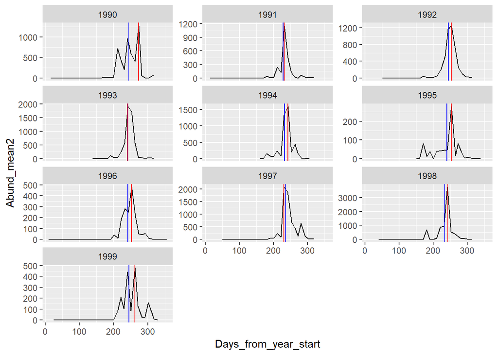

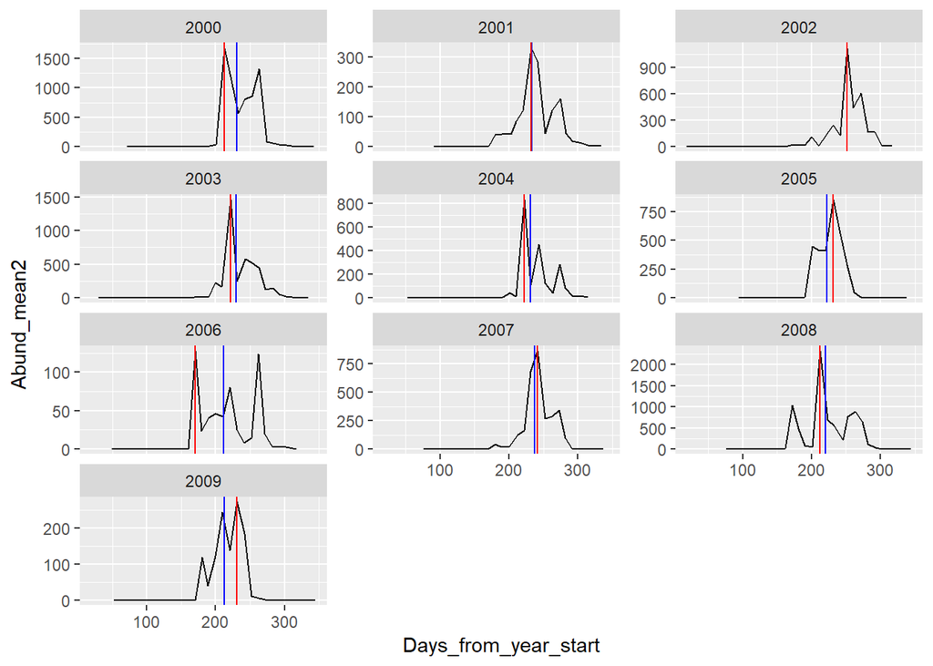

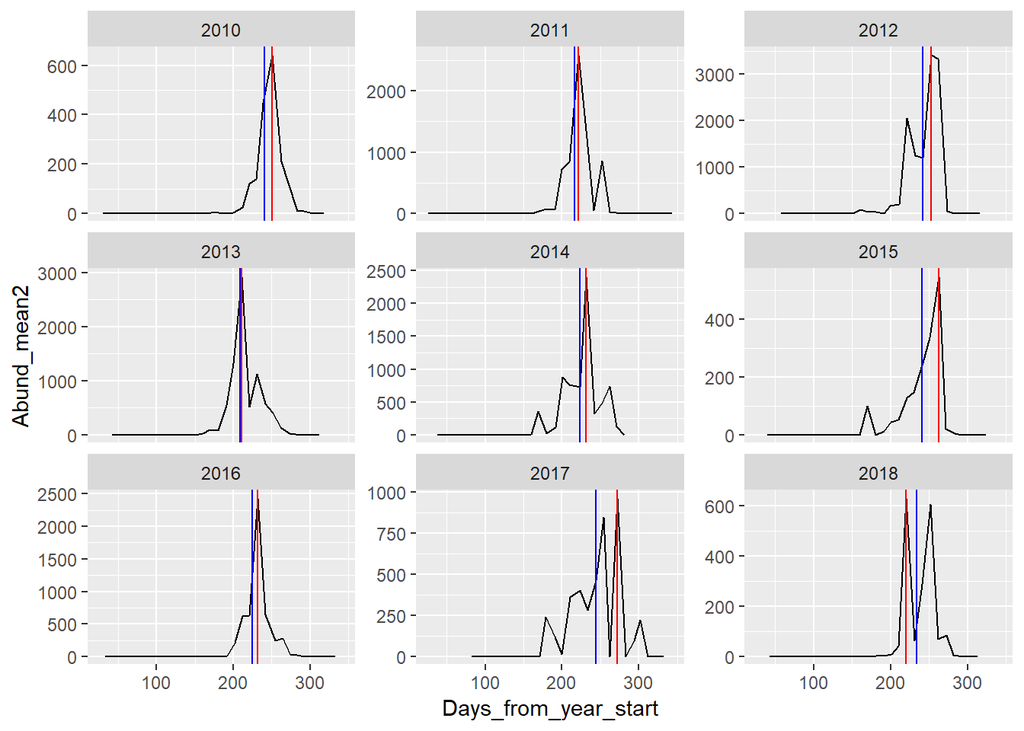

## Что надо сделать дальше

1. Понять как поступать с Calanus у которого есть много пропусков (Жду идей)
2. Построить общую фенологическую матрицу. Со всеми видами и всеми парамтерами (Сделаю, как только решим с п. 1)
3. Построить матрицу со среовыми параметрами, описывающими условия каждого года (Жду от тебя)
4. Сделать CCA или RDA по двум матрицам (как только будут выполнены пп 1-3, то все будет за 5 минут посчитано).